# Notas de Clase: Análisis factorial II — la rotación

¿Se pueden nombrar dos habilidades para dos perfiles de cargo?

Estadística Multidimensional · Universidad Distrital Francisco José de Caldas

Lunes 26 de octubre de 2026

# 1 Introducción: el cliente insiste

El sábado le dijimos al jefe de selección que la prueba mide **una sola habilidad común**, y que escritura e inglés tienen mucho de propio. Nos contesta:

> *«Entiendo, pero ya tengo aprobados dos perfiles de cargo. Si ustedes sacan dos habilidades, ¿no las pueden acomodar para que una sea la analítica y otra la comunicativa? Solo necesito dos nombres.»*

Es una petición razonable, y la técnica tiene una herramienta para eso: **girar la solución** para que cada módulo quede en una sola habilidad y se pueda nombrar. La pregunta de hoy:

> **Si giramos la solución de dos habilidades, ¿aparecen dos habilidades con nombre que sostengan dos perfiles de cargo distintos? ¿Y cuántas habilidades se pueden sacar, como máximo, de cinco módulos?**

# 2 Objetivos de aprendizaje

Al terminar la sesión, cada estudiante debe poder:

1. Explicar **qué es girar** una solución y **qué no cambia** al girarla.
2. Distinguir un giro que mantiene las habilidades **independientes** de uno que las deja **ir juntas**.
3. **Nombrar** una habilidad mirando sus cargas, y decir cuándo un nombre no se sostiene.
4. Decir **cuántas habilidades caben** en un número dado de variables.
5. **Traducir** el resultado a la decisión del cliente: cuántos perfiles de cargo sostiene la prueba.

# 3 La base con la que llegamos

```r
saber <- read.csv("PruebaSaber1.csv", sep = ";", fileEncoding = "latin1",
                  stringsAsFactors = FALSE)

s <- saber |>
  transmute(
    cuantitativo = MOD_RAZONA_CUANTITAT_PUNT,
    lectura      = MOD_LECTURA_CRITICA_PUNT,
    ciudadanas   = MOD_COMPETEN_CIUDADA_PUNT,
    ingles       = MOD_INGLES_PUNT,
    escritura    = MOD_COMUNI_ESCRITA_PUNT,
    estrato      = FAMI_ESTRATOVIVIENDA
  )
s$id <- seq_len(nrow(s))

modulos <- c("cuantitativo", "lectura", "ciudadanas", "ingles", "escritura")
etiqueta <- c(cuantitativo = "cuantitativo", lectura = "lectura", ciudadanas = "ciudadanas",
              ingles = "inglés", escritura = "escritura")

s <- s[s$estrato != "Empleado obrero u operario", ]
s$ingles[s$ingles == 0] <- NA
for (m in modulos) s[[m]][s$id %in% c(671, 614) & s[[m]] == 0] <- NA

X <- s[complete.cases(s[modulos]), modulos]
nrow(X)
```

```
## [1] 9907
```

# 4 Dos habilidades, sin girar

Empezamos donde terminamos el sábado: pedimos dos habilidades y miramos las cargas tal como salen.

```r
f_sin <- fa(X, nfactors = 2, fm = "ml", rotate = "none")
cargas_sin <- round(unclass(f_sin$loadings), 2)
colnames(cargas_sin) <- c("H1", "H2")
cargas_sin
```

```
##                H1    H2
## cuantitativo 0.56  0.36
## lectura      1.00 -0.01
## ciudadanas   0.64  0.32
## ingles       0.43  0.41
## escritura    0.32  0.25
```

> 📋 **Describir:** la primera habilidad carga en todos los módulos, de 0,32 a 1,00. La segunda tiene cargas pequeñas y mezcladas, entre -0,01 y 0,41.

> 🔎 **Analizar:** así no se puede nombrar nada: la primera carga en todos, pegada a lectura, y la segunda no tiene un módulo que mande. **Decisión:** hay que girar la solución para ver si aparece algo con nombre.

# 5 La idea de girar

> 📐 **La matemática, enunciada.** Las cargas de cada módulo son sus coordenadas en un plano cuyos ejes son las dos habilidades. **Girar** es cambiar los ejes sin mover los puntos:

> $$\text{cargas nuevas} = \text{cargas}
> \times \text{giro}$$

> y para cada módulo la parte común no cambia:

> $$\text{parte común}_i =
> \text{carga}_{i1}^2 + \text{carga}_{i2}^2 \quad \text{(igual antes y
> después de girar)}$$

> **En palabras:** los módulos se quedan quietos; lo que se mueve es **desde dónde los miramos**. Girar no cambia cuánto explica el modelo: solo busca los ejes desde los que **cada módulo cargue en una sola habilidad**, para que cada habilidad se pueda nombrar.

Hay dos maneras de girar:

| Giro | Qué permite | Cuándo tiene sentido |
| --- | --- | --- |
| **Que sigan independientes** (varimax) | Las dos habilidades no van juntas | Si uno cree que son capacidades sin relación |
| **Que puedan ir juntas** (oblimin) | Las dos habilidades pueden ir juntas | Casi siempre en personas: quien razona bien suele leer bien |

```r
f_ind <- fa(X, nfactors = 2, fm = "ml", rotate = "varimax")
f_jun <- fa(X, nfactors = 2, fm = "ml", rotate = "oblimin")

comun <- rbind(sin_girar       = f_sin$communality,
               independientes  = f_ind$communality,
               pueden_ir_juntas = f_jun$communality)
round(100 * comun, 1)
```

```
##                  cuantitativo lectura ciudadanas ingles escritura
## sin_girar                  44    99.5       50.7   35.3      16.4
## independientes             44    99.5       50.7   35.3      16.4
## pueden_ir_juntas           44    99.5       50.7   35.3      16.4
```

> 📋 **Describir:** la parte común de cada módulo es **exactamente la misma** con los tres giros: por ejemplo, escritura queda en 16,4 de cada 100 las tres veces.

> 🔎 **Analizar:** girar no inventa ni quita información: reparte la misma parte común entre las dos habilidades de otra manera. **Decisión:** podemos girar tranquilos; lo que hay que juzgar es si el resultado **se puede nombrar**.

# 6 ¿Qué aparece al girar?

```r
tabla <- data.frame(modulo = etiqueta[modulos],
                    independientes_H1 = round(f_ind$loadings[, 1], 2),
                    independientes_H2 = round(f_ind$loadings[, 2], 2),
                    juntas_H1 = round(f_jun$loadings[, 1], 2),
                    juntas_H2 = round(f_jun$loadings[, 2], 2), row.names = NULL)
tabla
```

| modulo | independientes_H1 | independientes_H2 | juntas_H1 | juntas_H2 |
| --- | --- | --- | --- | --- |
| cuantitativo | 0.36 | 0.56 | 0.60 | 0.08 |
| lectura | 0.91 | 0.41 | 0.01 | 0.99 |
| ciudadanas | 0.45 | 0.55 | 0.53 | 0.22 |
| inglés | 0.22 | 0.55 | 0.67 | -0.10 |
| escritura | 0.18 | 0.36 | 0.42 | -0.02 |

```r
c(con_giro_que_permite_ir_juntas_las_dos_van = round(f_jun$Phi[1, 2], 2))
```

```
## con_giro_que_permite_ir_juntas_las_dos_van
##                                       0.79
```

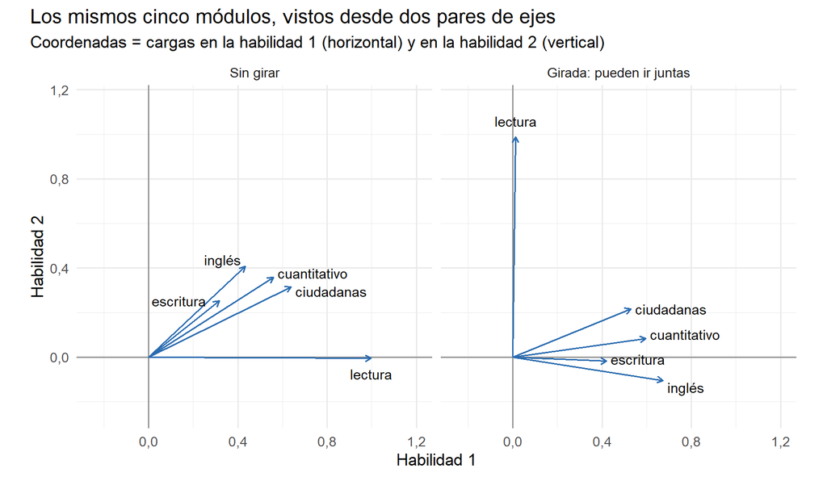

```r
plano <- bind_rows(
  data.frame(giro = "Sin girar", modulo = etiqueta[modulos],
             h1 = f_sin$loadings[, 1], h2 = f_sin$loadings[, 2]),
  data.frame(giro = "Girada: pueden ir juntas", modulo = etiqueta[modulos],
             h1 = f_jun$loadings[, 1], h2 = f_jun$loadings[, 2])) |>
  mutate(giro = factor(giro, levels = c("Sin girar", "Girada: pueden ir juntas")))
# posición de cada etiqueta, a mano, para que no se encimen
pos <- data.frame(
  giro = rep(c("Sin girar", "Girada: pueden ir juntas"), each = 5),
  modulo = rep(etiqueta[modulos], 2),
  dx = c(0.02, 0, 0.02, -0.02, -0.06,   0.02, 0, 0.02, 0.02, 0.02),
  dy = c(0.02, -0.07, -0.02, 0.03, 0,   0.02, 0.07, 0, -0.03, 0.01),
  hj = c(0, 0.5, 0, 1, 1,               0, 0.5, 0, 0, 0))
plano <- left_join(plano, pos, by = c("giro", "modulo")) |>
  mutate(giro = factor(giro, levels = c("Sin girar", "Girada: pueden ir juntas")))

ggplot(plano, aes(h1, h2)) +
  geom_hline(yintercept = 0, color = "grey60") + geom_vline(xintercept = 0, color = "grey60") +
  geom_segment(aes(xend = h1, yend = h2), x = 0, y = 0, color = "#2B6CB0",
               arrow = arrow(length = unit(0.18, "cm"))) +
  geom_text(aes(x = h1 + dx, y = h2 + dy, label = modulo, hjust = hj), size = 3.8) +
  facet_wrap(~ giro) +
  coord_equal(xlim = c(-0.25, 1.2), ylim = c(-0.25, 1.15), clip = "off") +
  scale_x_continuous(labels = function(x) coma(x, 1)) +
  scale_y_continuous(labels = function(x) coma(x, 1)) +
  labs(title = "Los mismos cinco módulos, vistos desde dos pares de ejes",
       subtitle = "Coordenadas = cargas en la habilidad 1 (horizontal) y en la habilidad 2 (vertical)",
       x = "Habilidad 1", y = "Habilidad 2")
```

> 📋 **Describir:** con el giro que mantiene las habilidades independientes, casi todos los módulos siguen cargando en las dos (cuantitativo 0,36 y 0,56). Con el giro que las deja ir juntas, **lectura queda sola en una habilidad** (0,99) y los otros cuatro en la otra, de 0,42 a 0,67. Y esas dos habilidades van juntas 0,79.

> 🔎 **Analizar:** el giro sí produjo algo «nombrable», pero no es lo que el cliente pidió: no hay una habilidad cuantitativa y otra verbal, sino **lectura** frente a **todo lo demás**. Y que vayan juntas 0,79 quiere decir que quien está alto en una casi siempre está alto en la otra. **Decisión:** antes de ponerles nombre, hay que ver si esta separación **es estable**.

# 7 ¿Es estable la segunda habilidad?

Una habilidad de verdad no debería depender del método con que se calcule. Probemos otro método de cálculo, con el mismo giro:

```r
f_otro <- fa(X, nfactors = 2, fm = "minres", rotate = "oblimin")
otro <- round(unclass(f_otro$loadings), 2); colnames(otro) <- c("H1", "H2")
rownames(otro) <- etiqueta[modulos]
otro
```

```
##                 H1    H2
## cuantitativo -0.02  0.75
## lectura       0.47  0.39
## ciudadanas    0.84 -0.02
## inglés        0.15  0.43
## escritura     0.24  0.17
```

```r
c(las_dos_van_juntas = round(f_otro$Phi[1, 2], 2))
```

```
## las_dos_van_juntas
##               0.79
```

> 📋 **Describir:** con otro método, la separación cambia: ahora una habilidad es sobre todo **ciudadanas** (0,84) y la otra sobre todo **cuantitativo** (0,75), con lectura repartida entre las dos. Las dos siguen yendo juntas 0,79.

> 🔎 **Analizar:** **la segunda habilidad cambia de forma según cómo se calcule**: una vez es lectura, otra vez es ciudadanas frente a cuantitativo. Una habilidad que se mueve con el método no es una habilidad de los estudiantes; es un acomodo de los números. Lo único estable es que las dos van juntas casi 0,8. **Decisión:** la prueba no sostiene dos habilidades con nombre.

# 8 ¿Cuántas habilidades caben en cinco módulos?

El cliente podría pedir tres. Hay un límite, y es aritmético.

> 📐 **La matemática, enunciada.** Con $p$ módulos hay $p(p-1)/2$ parejas, es decir, esa cantidad de correlaciones para explicar. Con $k$ habilidades, lo que el modelo deja «libre» para ser puesto a prueba es

> $$\text{grados de libertad} = \frac{(p -
> k)^2 - (p + k)}{2}$$

> **En palabras:** cada habilidad que se agrega gasta información. Cuando lo que queda llega a cero o se vuelve negativo, **el modelo ya no se puede comprobar con los datos**: explica todo porque tiene tantas piezas como datos.

```r
p <- length(modulos)
data.frame(habilidades = 1:3,
           correlaciones_a_explicar = p * (p - 1) / 2,
           grados_de_libertad = ((p - (1:3))^2 - (p + (1:3))) / 2)
```

| habilidades | correlaciones_a_explicar | grados_de_libertad |
| --- | --- | --- |
| 1 | 10 | 5 |
| 2 | 10 | 1 |
| 3 | 10 | -2 |

> 📋 **Describir:** con cinco módulos hay 10 correlaciones. Una habilidad deja 5 grados de libertad, dos dejan 1, y tres dan un número negativo.

> 🔎 **Analizar:** **con cinco módulos caben, como máximo, dos habilidades**, y la segunda ya casi no deja nada para comprobarla. Tres no se pueden sacar. **Decisión:** si el cliente quisiera tres perfiles, la prueba Saber no se los puede dar; necesitaría más pruebas o más variables.

Hay reglas automáticas que proponen un número de habilidades. Una muy usada compara los datos con datos revueltos al azar:

```r
set.seed(26)
paralelo <- fa.parallel(X, fm = "ml", fa = "fa", plot = FALSE)
```

```
## Parallel analysis suggests that the number of factors =  3  and the number of components =  NA
```

```r
c(la_regla_automatica_sugiere = paralelo$nfact)
```

```
## la_regla_automatica_sugiere
##                           3
```

> 📋 **Describir:** la regla automática sugiere 3 habilidades.

> 🔎 **Analizar:** con cinco módulos, 3 no se pueden sacar: los grados de libertad dan negativo. **Ninguna regla automática pasa por encima de ese límite.** **Decisión:** las reglas automáticas se usan como una opinión más, nunca como la respuesta. (Esta regla se llama análisis paralelo.)

# 9 El costo para el empleador

Supongamos que la empresa hace caso omiso y arma los dos perfiles con las dos habilidades giradas: contrata al 20 % más alto de cada una.

```r
f_pun <- fa(X, nfactors = 2, fm = "ml", rotate = "oblimin", scores = "regression")
H <- f_pun$scores
alto <- function(v) v >= quantile(v, 0.80)
perfil_1 <- alto(H[, 1]); perfil_2 <- alto(H[, 2])
c(perfil_1 = sum(perfil_1), perfil_2 = sum(perfil_2),
  en_los_dos = sum(perfil_1 & perfil_2),
  de_cada_100_repetidos = round(100 * sum(perfil_1 & perfil_2) / sum(perfil_1), 1))
```

```
##              perfil_1              perfil_2            en_los_dos
##                1982.0                1982.0                1492.0
## de_cada_100_repetidos
##                  75.3
```

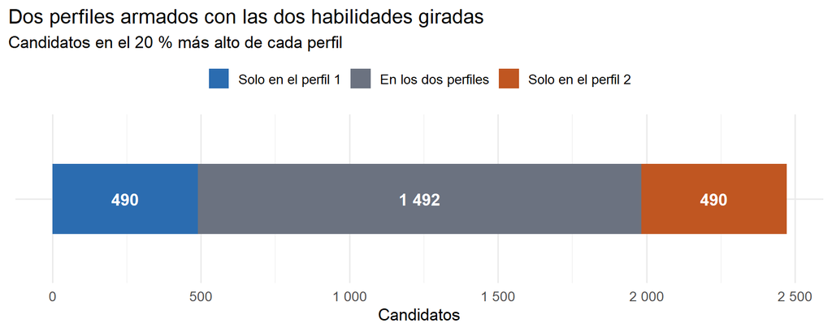

```r
data.frame(grupo = c("Solo en el perfil 1", "En los dos perfiles", "Solo en el perfil 2"),
           n = c(sum(perfil_1 & !perfil_2), sum(perfil_1 & perfil_2), sum(perfil_2 & !perfil_1))) |>
  mutate(grupo = factor(grupo, levels = grupo)) |>
  ggplot(aes(n, "", fill = grupo)) +
  geom_col(width = 0.5, position = position_stack(reverse = TRUE)) +
  geom_text(aes(label = miles(n)), position = position_stack(vjust = 0.5, reverse = TRUE),
            color = "white", fontface = "bold", size = 4.6) +
  scale_fill_manual(values = c("#2B6CB0", "#6B7280", "#C05621"), name = NULL) +
  scale_x_continuous(labels = miles) +
  labs(title = "Dos perfiles armados con las dos habilidades giradas",
       subtitle = "Candidatos en el 20 % más alto de cada perfil",
       x = "Candidatos", y = NULL) +
  theme(legend.position = "top")
```

> 📋 **Describir:** cada perfil escoge 1 982 candidatos, y 1 492 están en los dos: 75,3 de cada 100.

> 🔎 **Analizar:** los dos perfiles **escogen casi a la misma gente**. La empresa pagaría dos procesos de selección para obtener, en tres de cada cuatro casos, a los mismos candidatos. **Decisión:** un solo perfil de habilidad general, y los requisitos que de verdad distinguen —escritura e inglés— como módulos aparte.

# 10 Qué no es girar

- **No es hacer trampa.** Girar no cambia cuánto explica el modelo ni la parte común de ningún módulo.
- **No crea habilidades.** Si los datos tienen una sola habilidad fuerte, ningún giro va a producir dos que se sostengan.
- **El nombre lo ponemos nosotros.** Y un nombre solo vale si la habilidad es estable y si sirve para decidir algo distinto.

# 11 La puerta a lo que viene

| Lo que vimos | Lo que sigue | Cuándo |
| --- | --- | --- |
| Resumen (sesiones 3 y 4) y habilidades (5 y 6) | **Taller para entregar**: las dos técnicas sobre su dataset, para su cliente | **Sáb 31 oct** · sin clase |
| Grupos que se montan en una habilidad | **¿Son distintos estos grupos?** Comparar perfiles completos de dos grupos | **Sáb 7 nov** · taller para entregar |

# 12 Actividad práctica

Con **el dataset de su equipo**:

1. Saquen dos habilidades sin girar y miren si se pueden nombrar.
2. Gírenlas de las dos maneras (`rotate = "varimax"` y `rotate = "oblimin"`). Comprueben que la parte común de cada variable no cambia.
3. ¿Cuánto van juntas las dos habilidades con el giro que lo permite?
4. Cambien el método (`fm = "minres"`). ¿La separación se mantiene?
5. Con su número de variables, ¿cuántas habilidades caben como máximo?

# 13 Preguntas conceptuales

1. Si girar no cambia la parte común de ningún módulo, ¿para qué se gira?
2. ¿Por qué en personas casi siempre conviene el giro que deja ir juntas a las habilidades?
3. Dos habilidades van juntas 0,79. ¿Qué significa eso para quien quiere usarlas como dos perfiles?
4. ¿Por qué una habilidad que cambia según el método de cálculo no se puede nombrar?
5. Un equipo tiene 4 variables y quiere sacar 3 habilidades. ¿Qué le dice usted?
6. ¿Cuál de estas afirmaciones es correcta? **(a)** Girar aumenta la información que explica el modelo. **(b)** Girar cambia los ejes, no los módulos, y la parte común de cada módulo queda igual. **(c)** Con cinco módulos se pueden sacar hasta cinco habilidades. **(d)** Si el giro produce dos habilidades, la prueba mide dos habilidades.

# 14 Conclusión: lo que le entregamos al cliente

Al jefe de selección le respondemos:

- **Girar no cambia lo que la prueba mide**, solo desde dónde lo miramos. Lo intentamos de las dos maneras.
- **Al girar no aparece una habilidad analítica y otra comunicativa.** Aparece lectura frente al resto, o ciudadanas frente a cuantitativo, según el método: la segunda habilidad no es estable.
- **Y las dos van juntas casi 0,8:** si arma dos perfiles, tres de cada cuatro candidatos salen escogidos en los dos.
- **La decisión:** un perfil con la habilidad general y, para los cargos que lo requieran, **escritura e inglés como requisitos aparte**. Con cinco módulos no caben más de dos habilidades, y la prueba no sostiene ni siquiera la segunda.

La técnica de hoy se llama **rotación** en el análisis factorial. Lo que hicimos fue intentar, de buena fe, darle al cliente lo que pedía, y mostrarle con números por qué la prueba no se lo da.

# 15 Próxima semana

**Sábado 31 de octubre · Taller para entregar, sin clase.** Resumen y habilidades sobre el dataset de su equipo, para el cliente de su caso de negocio. Las instrucciones están en Moodle; se hace con las notas de las sesiones 3 a 6.